# Assessment 1

### Reg. No: 18BCE1010

### Name:R. Harini

### Frame any 10 questions for data manipulation

```r
rm(list=ls())
library(MASS)
library(dplyr)
```

```r
library(ggplot2)
df=Pima.tr
```

### Data Manipulation

```r
str(df)
```

```
## 'data.frame':    200 obs. of  8 variables:
##  $ npreg: int  5 7 5 0 0 5 3 1 3 2 ...
##  $ glu  : int  86 195 77 165 107 97 83 193 142 128 ...
##  $ bp   : int  68 70 82 76 60 76 58 50 80 78 ...
##  $ skin : int  28 33 41 43 25 27 31 16 15 37 ...
##  $ bmi  : num  30.2 25.1 35.8 47.9 26.4 35.6 34.3 25.9 32.4 43.3 ...
##  $ ped  : num  0.364 0.163 0.156 0.259 0.133 ...
##  $ age  : int  24 55 35 26 23 52 25 24 63 31 ...
##  $ type : Factor w/ 2 levels "No","Yes": 1 2 1 1 1 2 1 1 1 2 ...
```

```r
colnames(df)
```

```
## [1] "npreg" "glu"   "bp"    "skin"  "bmi"   "ped"   "age"   "type"
```

#### 1. Display npreg and age of people with type Yes

```r
df%>%
  filter(type=="Yes")%>%
  dplyr::select(npreg, age, type)
```

```
##    npreg age type
## 1      7  55  Yes
## 2      5  52  Yes
## 3      2  31  Yes
## 4      0  33  Yes
## 5      1  59  Yes
## 6     12  44  Yes
## 7     11  51  Yes
## 8      1  42  Yes
## 9      9  32  Yes
## 10     0  24  Yes
## 11     0  33  Yes
## 12     2  29  Yes
## 13     8  58  Yes
## 14     3  24  Yes
```

[output cut: 54 more lines]

#### 2. Find the max bmi who have diabetes type as Yes

```r
df%>%
  filter(type=="Yes")%>%
  summarise(max(bmi))
```

```
##   max(bmi)
## 1     46.1
```

#### 3. Create a new variable which is the average of glu and bp and add it to the dataset

```r
df=df%>%
  mutate(g_b=(glu+bp)/2)
df
```

```
##     npreg glu  bp skin  bmi   ped age type   g_b
## 1       5  86  68   28 30.2 0.364  24   No  77.0
## 2       7 195  70   33 25.1 0.163  55  Yes 132.5
## 3       5  77  82   41 35.8 0.156  35   No  79.5
## 4       0 165  76   43 47.9 0.259  26   No 120.5
## 5       0 107  60   25 26.4 0.133  23   No  83.5
## 6       5  97  76   27 35.6 0.378  52  Yes  86.5
## 7       3  83  58   31 34.3 0.336  25   No  70.5
## 8       1 193  50   16 25.9 0.655  24   No 121.5
## 9       3 142  80   15 32.4 0.200  63   No 111.0
## 10      2 128  78   37 43.3 1.224  31  Yes 103.0
## 11      0 137  40   35 43.1 2.288  33  Yes  88.5
## 12      9 154  78   30 30.9 0.164  45   No 116.0
## 13      1 189  60   23 30.1 0.398  59  Yes 124.5
## 14     12  92  62    7 27.6 0.926  44  Yes  77.0
```

[output cut: 186 more lines]

#### 4. Arranging the dataset in descending order according to age for all type “Yes”

```r
arrange(df, desc(age))%>%filter(type=="Yes")
```

```
##    npreg glu  bp skin  bmi   ped age type   g_b
## 1      2 197  70   99 34.7 0.575  62  Yes 133.5
## 2      8 181  68   36 30.1 0.615  60  Yes 124.5
## 3      1 189  60   23 30.1 0.398  59  Yes 124.5
## 4      8 176  90   34 33.7 0.467  58  Yes 133.0
## 5     12 140  82   43 39.2 0.528  58  Yes 111.0
## 6      5 144  82   26 32.0 0.452  58  Yes 113.0
## 7      7 195  70   33 25.1 0.163  55  Yes 132.5
## 8      7 150  78   29 35.2 0.692  54  Yes 114.0
## 9      5  97  76   27 35.6 0.378  52  Yes  86.5
## 10     1 168  88   29 35.0 0.905  52  Yes 128.0
## 11     8 124  76   24 28.7 0.687  52  Yes 100.0
## 12    11 143  94   33 36.6 0.254  51  Yes 118.5
## 13    10 148  84   48 37.6 1.001  51  Yes 116.0
## 14     6 125  78   31 27.6 0.565  49  Yes 101.5
```

[output cut: 54 more lines]

#### 5. Find the standard deviation of bp for type Yes and No

```r
df%>%
  group_by(type)%>%
  summarise(sd(bp))
```

```
## # A tibble: 2 x 2
##   type  `sd(bp)`
##   <fct>    <dbl>
## 1 No        11.1
## 2 Yes       11.6
```

#### 6. Display bp and glu of those who have type Yes and age above 30

```r
df%>%
  filter(type=="Yes" & age>30)%>%
  dplyr::select(bp, glu, type, age)
```

```
##     bp glu type age
## 1   70 195  Yes  55
## 2   76  97  Yes  52
## 3   78 128  Yes  31
## 4   40 137  Yes  33
## 5   60 189  Yes  59
## 6   62  92  Yes  44
## 7   94 143  Yes  51
## 8   68 149  Yes  42
## 9   84 164  Yes  32
## 10  66 121  Yes  33
## 11  90 176  Yes  58
## 12  78 154  Yes  45
## 13 106 167  Yes  43
## 14  84 184  Yes  41
```

[output cut: 33 more lines]

#### 7. Find the average of bp, glu for people with age below 30 and bmi above 30 with type Yes and No

```r
df%>%
  filter(age<30 & bmi>30)%>%
  group_by(type)%>%
  summarise(mean(bp), mean(glu))
```

```
## # A tibble: 2 x 3
##   type  `mean(bp)` `mean(glu)`
##   <fct>      <dbl>       <dbl>
## 1 No          68.2        111.
## 2 Yes         72.4        145.
```

#### 8. Display the variance of bmi for people with npreg above the average npreg and skin below 20

```r
df%>%
  filter(npreg>mean(npreg) & skin<20)%>%
  summarise(var(bmi))
```

```
##   var(bmi)
## 1 14.11073
```

#### 9. Arrange the dataset in ascending order of bmi with skin below 25 and ped above 1

```r
arrange(df, bmi)%>%
  filter(skin<25 & ped>1)
```

```
##   npreg glu bp skin  bmi   ped age type  g_b
## 1     2  92 76   20 24.2 1.698  28   No 84.0
## 2     1  97 68   21 27.2 1.095  22   No 82.5
```

#### 10. Group the dataset based on Type for all those who have age higher than the mean and find the variance of bp

```r
df%>%
  group_by(type)%>%
  filter(age>mean(age))%>%
  summarise(var(bp))
```

```
## # A tibble: 2 x 2
##   type  `var(bp)`
##   <fct>     <dbl>
## 1 No         98.5
## 2 Yes       132.
```

### Visualisation

#### 1. Visualising the range of Age

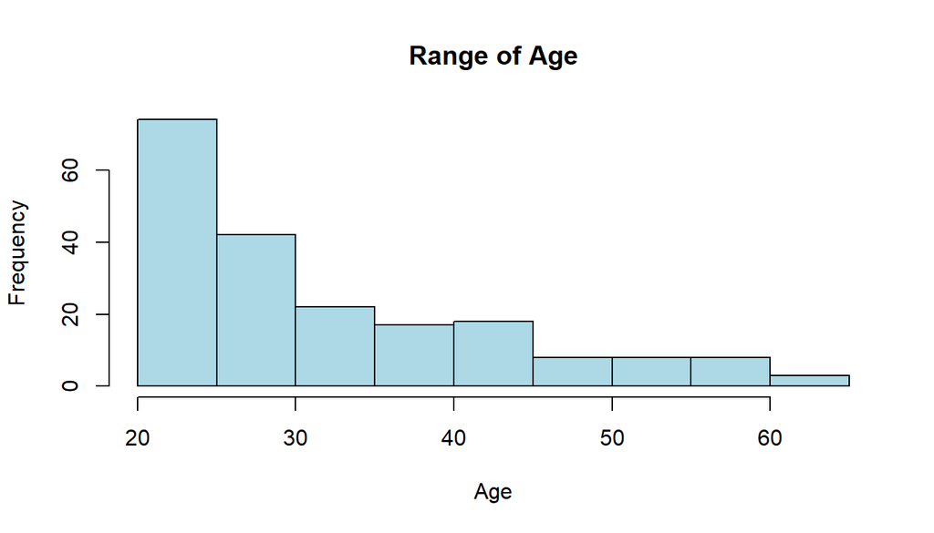

```r
hist(df$age, main="Range of Age", xlab = "Age", col = "light blue")
```

#### 2. Visualising the frequency of Type Yes and No

```r
c=df%>%
  group_by(type)%>%
  tally()
c
```

```
## # A tibble: 2 x 2
##   type      n
##   <fct> <int>
## 1 No      132
## 2 Yes      68
```

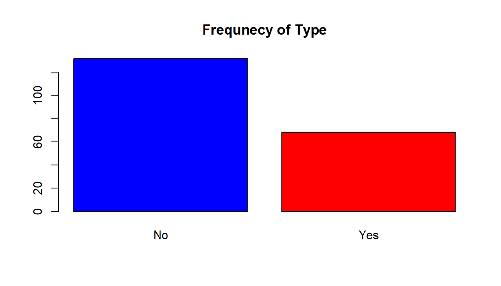

```r
barplot(c$n, main="Frequnecy of Type", names.arg = c$type, col=c("blue", "red"))
```

#### 3. visualising the summary statistics of bp

```r
summary(df$bp)
```

```
##    Min. 1st Qu.  Median    Mean 3rd Qu.    Max.
##   38.00   64.00   70.00   71.26   78.00  110.00
```

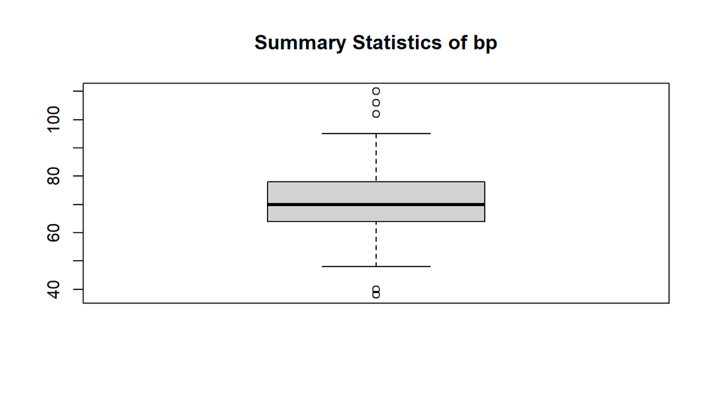

```r
boxplot(df$bp, main="Summary Statistics of bp")
```

#### 4. Scatter plot between Glu and Skin

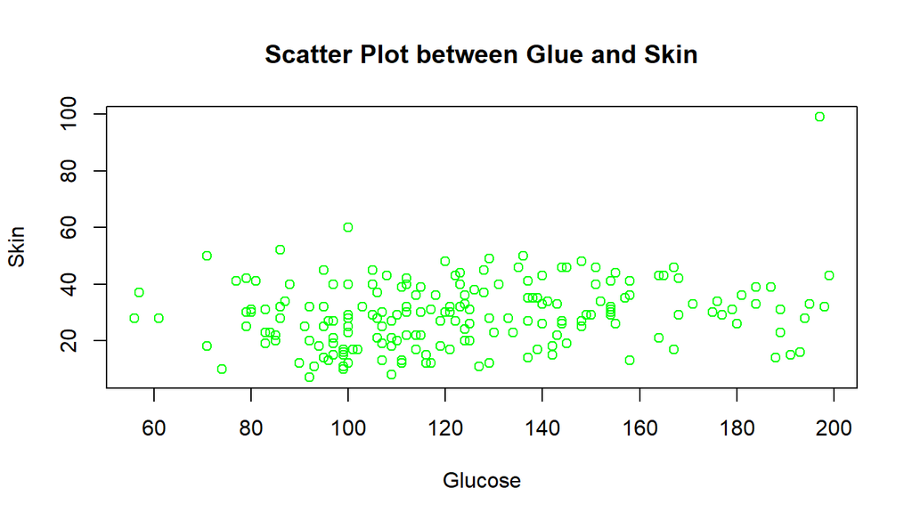

```r
plot(df$glu, df$skin, main = "Scatter Plot between Glue and Skin", xlab = "Glucose", ylab="Skin", col="green")
```

#### 5. Scatter plot between BMI and Ped for each Type

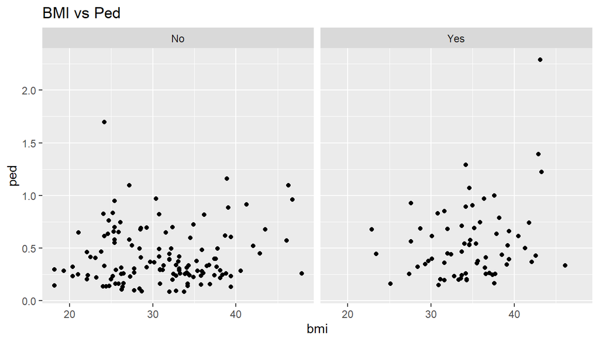

```r
ggplot(df, aes(x=bmi, y=ped))+geom_point()+facet_wrap(~type)+labs(title="BMI vs Ped")
```

#### 6. A Pie Chart for number of Yes and No taking npreg as the levels

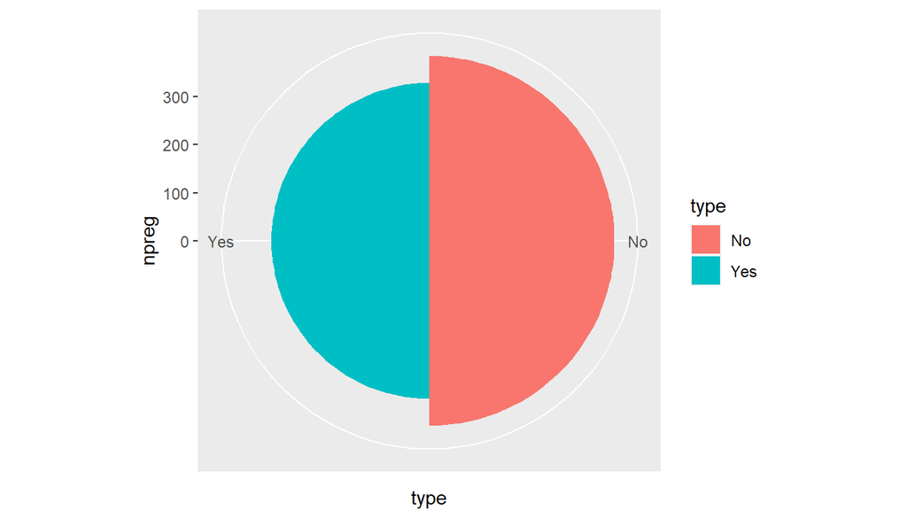

```r
ggplot(df, aes(x=npreg,y=type, fill=type))+geom_bar(stat="identity", width=1)+coord_polar("y", start=0)
```

#### 7. Density plot of Bp

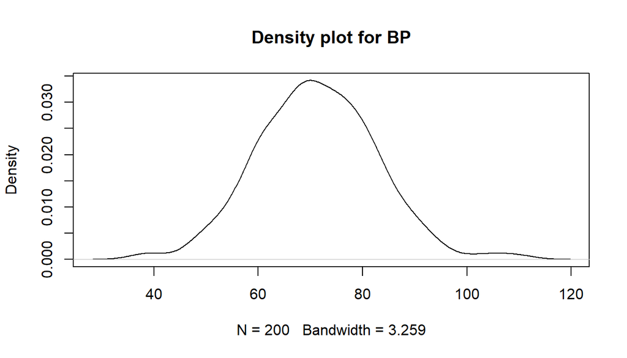

```r
d=density(df$bp)
plot(d, main="Density plot for BP")
```

#### 8. Creating the scatter Plot for Bp, Bmi with varying size based on Ped

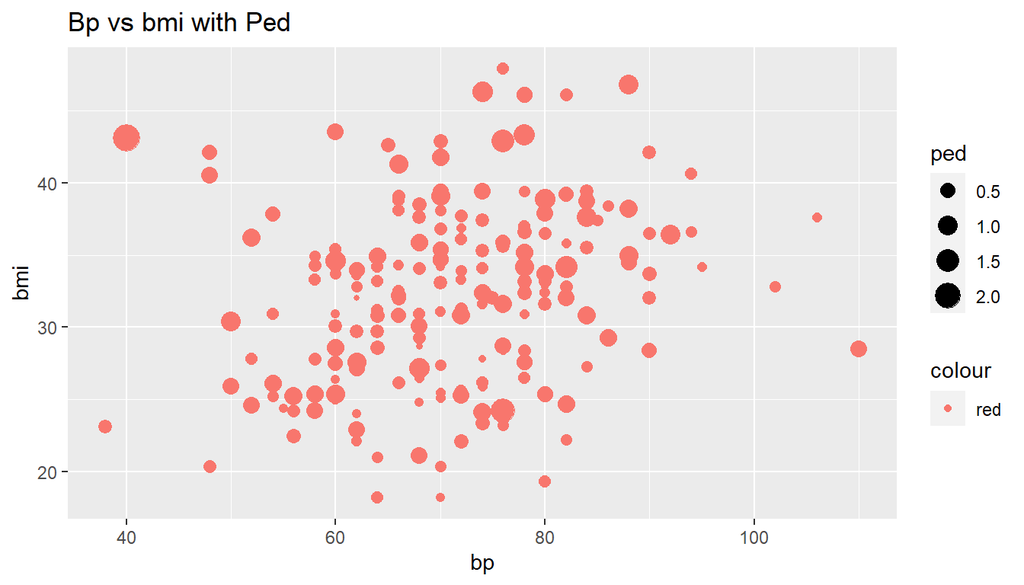

```r
ggplot(df, aes(x=bp, y=bmi, size=ped, col="red"))+geom_point()+labs(title = "Bp vs bmi with Ped")
```

#### 9. Creating a Scatter Plot between Glu and Age with Type as Shape

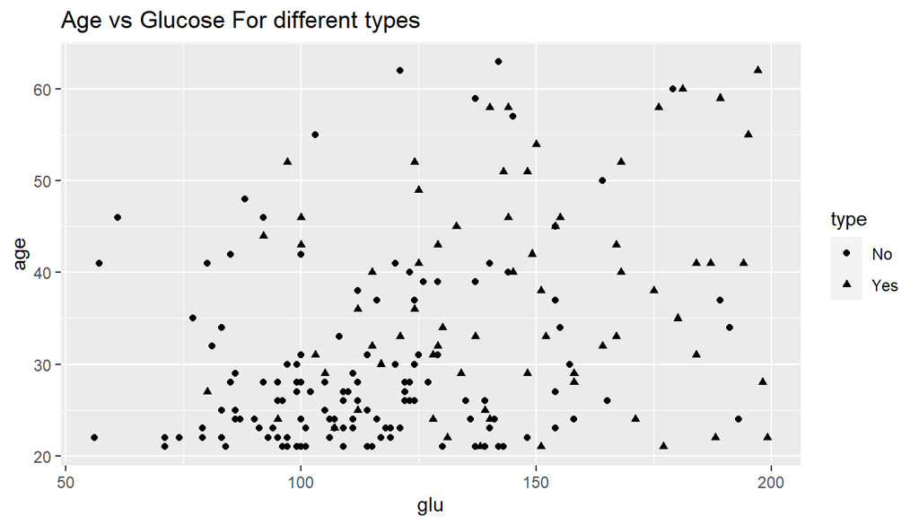

```r
ggplot(df, aes(x=glu, y=age, shape=type))+geom_point()+labs(title = "Age vs Glucose For different types")
```

#### 10. Adding a best fit line to Skin vs Age

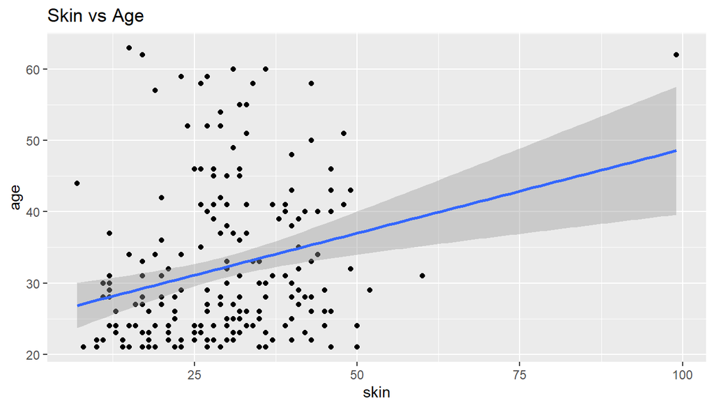

```r
ggplot(df, aes(x=skin, y=age))+geom_point()+geom_smooth(method = 'lm')+labs(title="Skin vs Age")
```